# sigident - Howto Microarray

### GSE33356

#### Lasso (min)

```r
validation_results[["GSE33356"]]$lasso$min$confmat
```

```
#> Confusion Matrix and Statistics
#>
#>           Reference
#> Prediction  0  1
#>          0 60 33
#>          1  0 27
#>
#>                Accuracy : 0.725
#>                  95% CI : (0.636, 0.8025)
#>     No Information Rate : 0.5
#>     P-Value [Acc > NIR] : 4.34e-07
#>
#>                   Kappa : 0.45
#>
#>  Mcnemar's Test P-Value : 2.54e-08
#>
#>             Sensitivity : 0.4500
#>             Specificity : 1.0000
#>          Pos Pred Value : 1.0000
#>          Neg Pred Value : 0.6452
#>              Prevalence : 0.5000
#>          Detection Rate : 0.2250
#>    Detection Prevalence : 0.2250
#>       Balanced Accuracy : 0.7250
#>
#>        'Positive' Class : 1
#>
```

```r
# create roc plot
filename <- paste0(plotdir, "ROC_validation_GSE33356_lasso_min.png")
sigident::plot_rocplot(roc = validation_results[["GSE33356"]]$lasso$min$roc,
                       filename = filename)
```

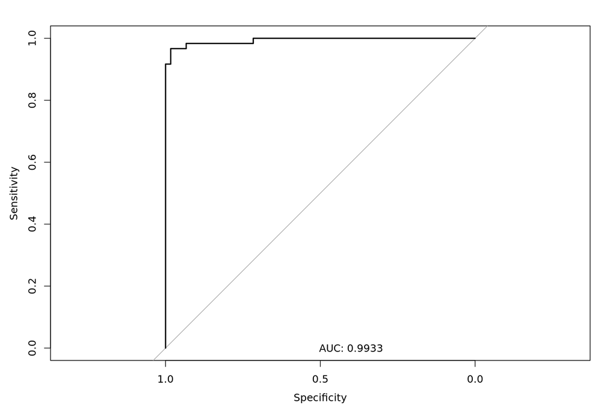

```r
knitr::include_graphics(filename)
```

#### Lasso (1se)

```r
validation_results[["GSE33356"]]$lasso[["1se"]]$confmat
```

```
#> Confusion Matrix and Statistics
#>
#>           Reference
#> Prediction  0  1
#>          0 60 26
#>          1  0 34
#>
#>                Accuracy : 0.7833
#>                  95% CI : (0.6989, 0.8533)
#>     No Information Rate : 0.5
#>     P-Value [Acc > NIR] : 1.570e-10
#>
#>                   Kappa : 0.5667
#>
#>  Mcnemar's Test P-Value : 9.443e-07
#>
#>             Sensitivity : 0.5667
#>             Specificity : 1.0000
#>          Pos Pred Value : 1.0000
#>          Neg Pred Value : 0.6977
#>              Prevalence : 0.5000
#>          Detection Rate : 0.2833
#>    Detection Prevalence : 0.2833
#>       Balanced Accuracy : 0.7833
#>
#>        'Positive' Class : 1
#>
```

```r
# create roc plot
filename <- paste0(plotdir, "ROC_validation_GSE33356_lasso_1se.png")
sigident::plot_rocplot(roc = validation_results[["GSE33356"]]$lasso[["1se"]]$roc,
                       filename = filename)
```

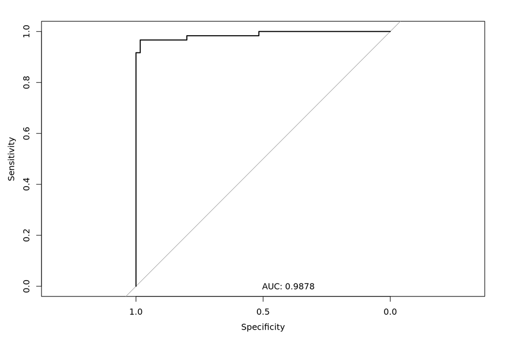

```r
knitr::include_graphics(filename)
```

#### Elastic (min)

```r
validation_results[["GSE33356"]]$elasticnet$min$confmat
```

```
#> Confusion Matrix and Statistics
#>
#>           Reference
#> Prediction  0  1
#>          0 60 25
#>          1  0 35
#>
#>                Accuracy : 0.7917
#>                  95% CI : (0.708, 0.8604)
#>     No Information Rate : 0.5
#>     P-Value [Acc > NIR] : 4.222e-11
#>
#>                   Kappa : 0.5833
#>
#>  Mcnemar's Test P-Value : 1.587e-06
#>
#>             Sensitivity : 0.5833
#>             Specificity : 1.0000
#>          Pos Pred Value : 1.0000
#>          Neg Pred Value : 0.7059
#>              Prevalence : 0.5000
#>          Detection Rate : 0.2917
#>    Detection Prevalence : 0.2917
#>       Balanced Accuracy : 0.7917
#>
#>        'Positive' Class : 1
#>
```

```r
# create roc plot
filename <- paste0(plotdir, "ROC_validation_GSE33356_elasticnet_min.png")
sigident::plot_rocplot(roc = validation_results[["GSE33356"]]$elasticnet$min$roc,
                       filename = filename)
```

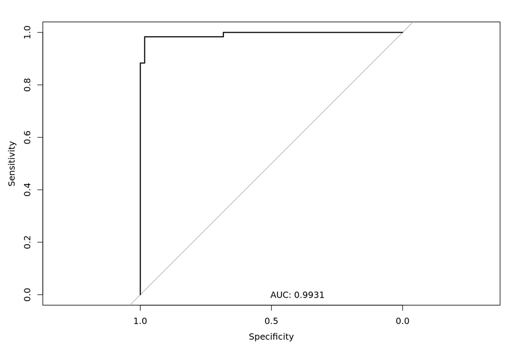

```r
knitr::include_graphics(filename)
```

#### Elastic (1se)

```r
validation_results[["GSE33356"]]$elasticnet[["1se"]]$confmat
```

```
#> Confusion Matrix and Statistics
#>
#>           Reference
#> Prediction  0  1
#>          0 60 28
#>          1  0 32
#>
#>                Accuracy : 0.7667
#>                  95% CI : (0.6807, 0.839)
#>     No Information Rate : 0.5
#>     P-Value [Acc > NIR] : 1.884e-09
#>
#>                   Kappa : 0.5333
#>
#>  Mcnemar's Test P-Value : 3.352e-07
#>
#>             Sensitivity : 0.5333
#>             Specificity : 1.0000
#>          Pos Pred Value : 1.0000
#>          Neg Pred Value : 0.6818
#>              Prevalence : 0.5000
#>          Detection Rate : 0.2667
#>    Detection Prevalence : 0.2667
#>       Balanced Accuracy : 0.7667
#>
#>        'Positive' Class : 1
#>
```

```r
# create roc plot
filename <- paste0(plotdir, "ROC_validation_GSE33356_elasticnet_1se.png")
sigident::plot_rocplot(roc = validation_results[["GSE33356"]]$elasticnet[["1se"]]$roc,
                       filename = filename)
```

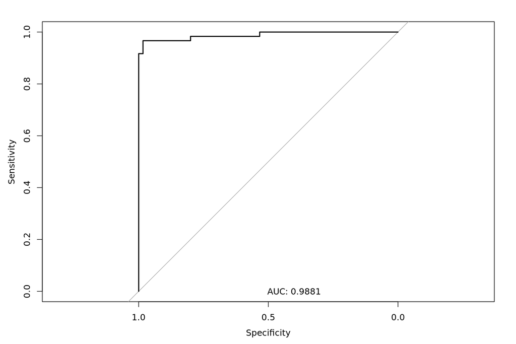

```r
knitr::include_graphics(filename)
```

#### Elasticnet gridsearch (best model)

```r
validation_results[["GSE33356"]]$glmnet$confmat
```

```
#> Confusion Matrix and Statistics
#>
#>           Reference
#> Prediction  0  1
#>          0 60 24
#>          1  0 36
#>
#>                Accuracy : 0.8
#>                  95% CI : (0.7172, 0.8675)
#>     No Information Rate : 0.5
#>     P-Value [Acc > NIR] : 1.081e-11
#>
#>                   Kappa : 0.6
#>
#>  Mcnemar's Test P-Value : 2.668e-06
#>
#>             Sensitivity : 0.6000
#>             Specificity : 1.0000
#>          Pos Pred Value : 1.0000
#>          Neg Pred Value : 0.7143
#>              Prevalence : 0.5000
#>          Detection Rate : 0.3000
#>    Detection Prevalence : 0.3000
#>       Balanced Accuracy : 0.8000
#>
#>        'Positive' Class : 1
#>
```

```r
# create roc plot
filename <- paste0(plotdir, "ROC_validation_GSE33356_glmnet.png")
sigident::plot_rocplot(roc = validation_results[["GSE33356"]]$glmnet$roc,
                       filename = filename)
```

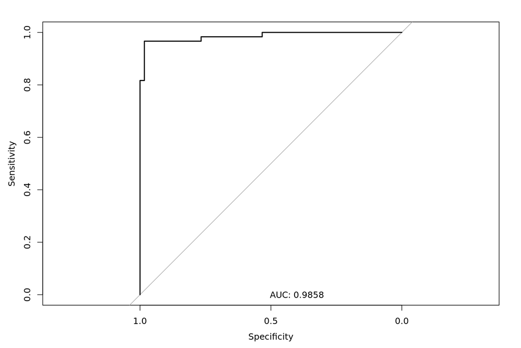

```r
knitr::include_graphics(filename)
```

#### SVM

```r
validation_results[["GSE33356"]]$svm$confmat
```

```
#> Confusion Matrix and Statistics
#>
#>           Reference
#> Prediction  0  1
#>          0 60 60
#>          1  0  0
#>
#>                Accuracy : 0.5
#>                  95% CI : (0.4074, 0.5926)
#>     No Information Rate : 0.5
#>     P-Value [Acc > NIR] : 0.5363
#>
#>                   Kappa : 0
#>
#>  Mcnemar's Test P-Value : 2.599e-14
#>
#>             Sensitivity : 0.0
#>             Specificity : 1.0
#>          Pos Pred Value : NaN
#>          Neg Pred Value : 0.5
#>              Prevalence : 0.5
#>          Detection Rate : 0.0
#>    Detection Prevalence : 0.0
#>       Balanced Accuracy : 0.5
#>
#>        'Positive' Class : 1
#>
```

```r
# create roc plot
filename <- paste0(plotdir, "ROC_validation_GSE33356_svm.png")
sigident::plot_rocplot(roc = validation_results[["GSE33356"]]$svm$roc,
                       filename = filename)
```

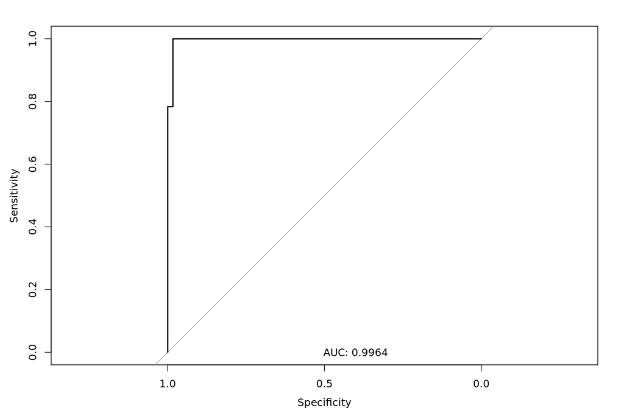

```r
knitr::include_graphics(filename)
```

#### RF

```r
validation_results[["GSE33356"]]$rf$confmat
```

```
#> Confusion Matrix and Statistics
#>
#>           Reference
#> Prediction  0  1
#>          0  8  2
#>          1 52 58
#>
#>                Accuracy : 0.55
#>                  95% CI : (0.4565, 0.6409)
#>     No Information Rate : 0.5
#>     P-Value [Acc > NIR] : 0.1577
#>
#>                   Kappa : 0.1
#>
#>  Mcnemar's Test P-Value : 2.592e-11
#>
#>             Sensitivity : 0.9667
#>             Specificity : 0.1333
#>          Pos Pred Value : 0.5273
#>          Neg Pred Value : 0.8000
#>              Prevalence : 0.5000
#>          Detection Rate : 0.4833
#>    Detection Prevalence : 0.9167
#>       Balanced Accuracy : 0.5500
#>
#>        'Positive' Class : 1
#>
```

```r
# create roc plot
filename <- paste0(plotdir, "ROC_validation_GSE33356_rf.png")
sigident::plot_rocplot(roc = validation_results[["GSE33356"]]$rf$roc,
                       filename = filename)
```

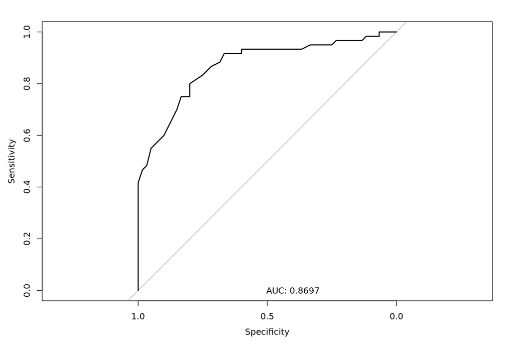

```r
knitr::include_graphics(filename)
```

#### KNN

```r
validation_results[["GSE33356"]]$knn$confmat
```

```
#> Confusion Matrix and Statistics
#>
#>           Reference
#> Prediction  0  1
#>          0 25  6
#>          1 35 54
#>
#>                Accuracy : 0.6583
#>                  95% CI : (0.5662, 0.7424)
#>     No Information Rate : 0.5
#>     P-Value [Acc > NIR] : 0.0003334
#>
#>                   Kappa : 0.3167
#>
#>  Mcnemar's Test P-Value : 1.226e-05
#>
#>             Sensitivity : 0.9000
#>             Specificity : 0.4167
#>          Pos Pred Value : 0.6067
#>          Neg Pred Value : 0.8065
#>              Prevalence : 0.5000
#>          Detection Rate : 0.4500
#>    Detection Prevalence : 0.7417
#>       Balanced Accuracy : 0.6583
#>
#>        'Positive' Class : 1
#>
```

```r
# create roc plot
filename <- paste0(plotdir, "ROC_validation_GSE33356_knn.png")
sigident::plot_rocplot(roc = validation_results[["GSE33356"]]$knn$roc,
                       filename = filename)
```

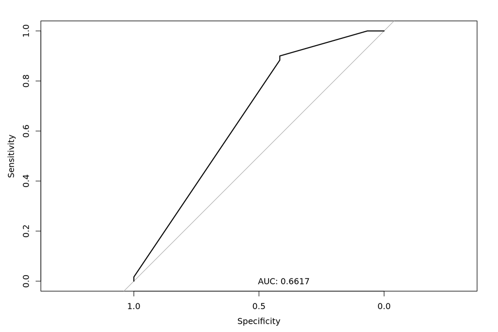

```r
knitr::include_graphics(filename)
```

```r
validation_results[["GSE33356"]] <- NULL
gc()
```

### GSE102287

#### Lasso (min)

```r
validation_results[["GSE102287"]]$lasso$min$confmat
```

```
#> Confusion Matrix and Statistics
#>
#>           Reference
#> Prediction  0  1
#>          0 32  5
#>          1  2 27
#>
#>                Accuracy : 0.8939
#>                  95% CI : (0.7936, 0.9563)
#>     No Information Rate : 0.5152
#>     P-Value [Acc > NIR] : 5.636e-11
#>
#>                   Kappa : 0.7871
#>
#>  Mcnemar's Test P-Value : 0.4497
#>
#>             Sensitivity : 0.8438
#>             Specificity : 0.9412
#>          Pos Pred Value : 0.9310
#>          Neg Pred Value : 0.8649
#>              Prevalence : 0.4848
#>          Detection Rate : 0.4091
#>    Detection Prevalence : 0.4394
#>       Balanced Accuracy : 0.8925
#>
#>        'Positive' Class : 1
#>
```

```r
# create roc plot
filename <- paste0(plotdir, "ROC_validation_GSE102287_lasso_min.png")
sigident::plot_rocplot(roc = validation_results[["GSE102287"]]$lasso$min$roc,
                       filename = filename)
```

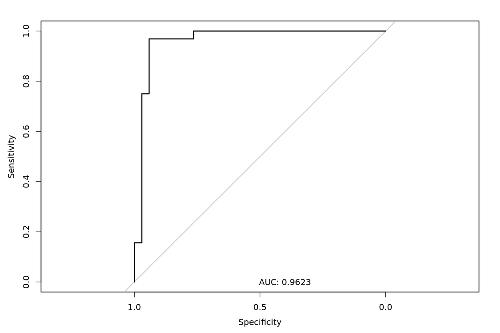

```r
knitr::include_graphics(filename)
```

#### Lasso (1se)

```r
validation_results[["GSE102287"]]$lasso[["1se"]]$confmat
```

```
#> Confusion Matrix and Statistics
#>
#>           Reference
#> Prediction  0  1
#>          0 32  2
#>          1  2 30
#>
#>                Accuracy : 0.9394
#>                  95% CI : (0.852, 0.9832)
#>     No Information Rate : 0.5152
#>     P-Value [Acc > NIR] : 5.887e-14
#>
#>                   Kappa : 0.8787
#>
#>  Mcnemar's Test P-Value : 1
#>
#>             Sensitivity : 0.9375
#>             Specificity : 0.9412
#>          Pos Pred Value : 0.9375
#>          Neg Pred Value : 0.9412
#>              Prevalence : 0.4848
#>          Detection Rate : 0.4545
#>    Detection Prevalence : 0.4848
#>       Balanced Accuracy : 0.9393
#>
#>        'Positive' Class : 1
#>
```

```r
# create roc plot
filename <- paste0(plotdir, "ROC_validation_GSE102287_lasso_1se.png")
sigident::plot_rocplot(roc = validation_results[["GSE102287"]]$lasso[["1se"]]$roc,
                       filename = filename)
```

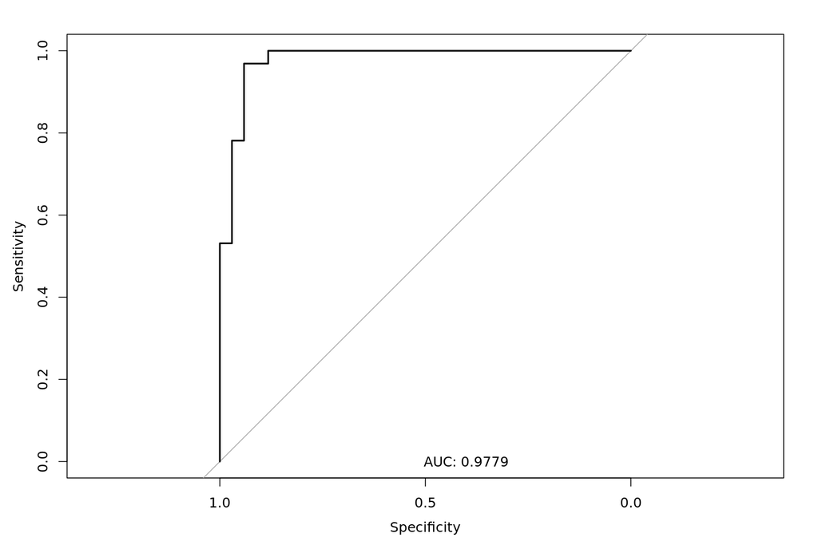

```r
knitr::include_graphics(filename)
```

#### Elastic (min)

```r
validation_results[["GSE102287"]]$elasticnet$min$confmat
```

```
#> Confusion Matrix and Statistics
#>
#>           Reference
#> Prediction  0  1
#>          0 32  2
#>          1  2 30
#>
#>                Accuracy : 0.9394
#>                  95% CI : (0.852, 0.9832)
#>     No Information Rate : 0.5152
#>     P-Value [Acc > NIR] : 5.887e-14
#>
#>                   Kappa : 0.8787
#>
#>  Mcnemar's Test P-Value : 1
#>
#>             Sensitivity : 0.9375
#>             Specificity : 0.9412
#>          Pos Pred Value : 0.9375
#>          Neg Pred Value : 0.9412
#>              Prevalence : 0.4848
#>          Detection Rate : 0.4545
#>    Detection Prevalence : 0.4848
#>       Balanced Accuracy : 0.9393
#>
#>        'Positive' Class : 1
#>
```

```r
# create roc plot
filename <- paste0(plotdir, "ROC_validation_GSE102287_elasticnet_min.png")
sigident::plot_rocplot(roc = validation_results[["GSE102287"]]$elasticnet$min$roc,
                       filename = filename)
```

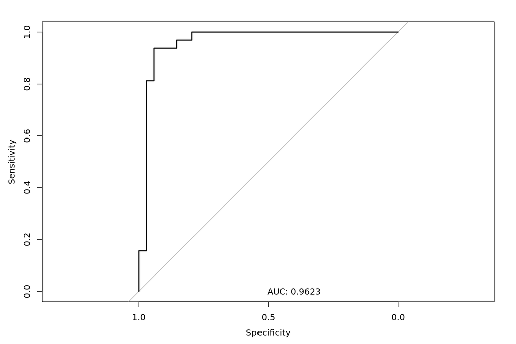

```r
knitr::include_graphics(filename)
```

#### Elastic (1se)

```r
validation_results[["GSE102287"]]$elasticnet[["1se"]]$confmat
```

```
#> Confusion Matrix and Statistics
#>
#>           Reference
#> Prediction  0  1
#>          0 32  2
#>          1  2 30
#>
#>                Accuracy : 0.9394
#>                  95% CI : (0.852, 0.9832)
#>     No Information Rate : 0.5152
#>     P-Value [Acc > NIR] : 5.887e-14
#>
#>                   Kappa : 0.8787
#>
#>  Mcnemar's Test P-Value : 1
#>
#>             Sensitivity : 0.9375
#>             Specificity : 0.9412
#>          Pos Pred Value : 0.9375
#>          Neg Pred Value : 0.9412
#>              Prevalence : 0.4848
#>          Detection Rate : 0.4545
#>    Detection Prevalence : 0.4848
#>       Balanced Accuracy : 0.9393
#>
#>        'Positive' Class : 1
#>
```

```r
# create roc plot
filename <- paste0(plotdir, "ROC_validation_GSE102287_elasticnet_1se.png")
sigident::plot_rocplot(roc = validation_results[["GSE102287"]]$elasticnet[["1se"]]$roc,
                       filename = filename)
```

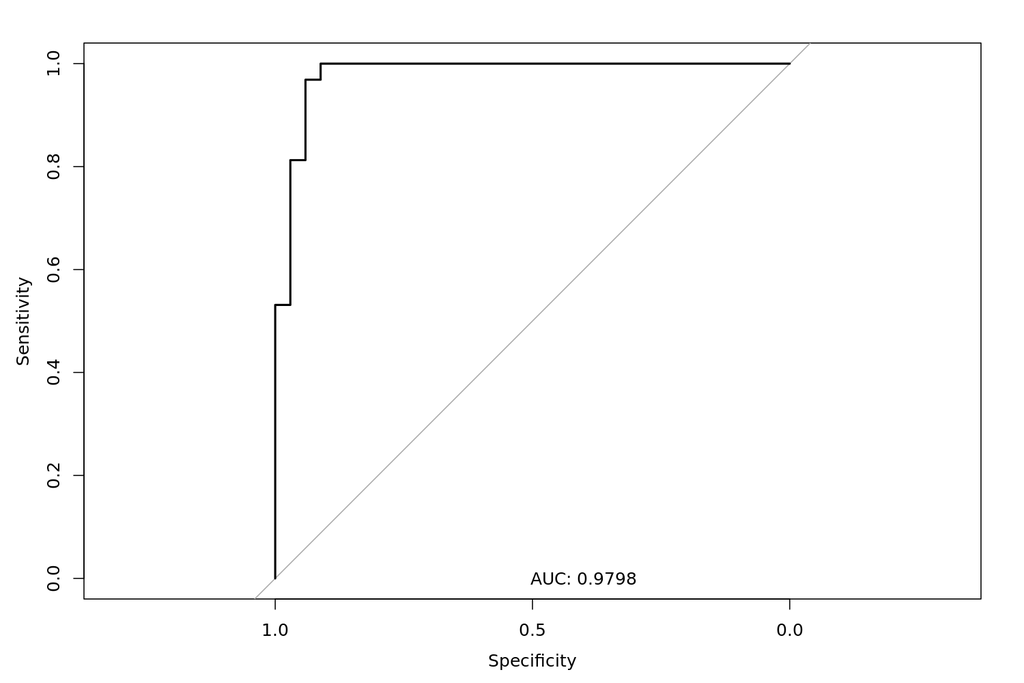

```r
knitr::include_graphics(filename)
```

#### Elasticnet gridsearch (best model)

```r
validation_results[["GSE102287"]]$glmnet$confmat
```

```
#> Confusion Matrix and Statistics
#>
#>           Reference
#> Prediction  0  1
#>          0 32  1
#>          1  2 31
#>
#>                Accuracy : 0.9545
#>                  95% CI : (0.8729, 0.9905)
#>     No Information Rate : 0.5152
#>     P-Value [Acc > NIR] : 3.899e-15
#>
#>                   Kappa : 0.9091
#>
#>  Mcnemar's Test P-Value : 1
#>
#>             Sensitivity : 0.9688
#>             Specificity : 0.9412
#>          Pos Pred Value : 0.9394
#>          Neg Pred Value : 0.9697
#>              Prevalence : 0.4848
#>          Detection Rate : 0.4697
#>    Detection Prevalence : 0.5000
#>       Balanced Accuracy : 0.9550
#>
#>        'Positive' Class : 1
#>
```

```r
# create roc plot
filename <- paste0(plotdir, "ROC_validation_GSE102287_glmnet.png")
sigident::plot_rocplot(roc = validation_results[["GSE102287"]]$glmnet$roc,
                       filename = filename)
```

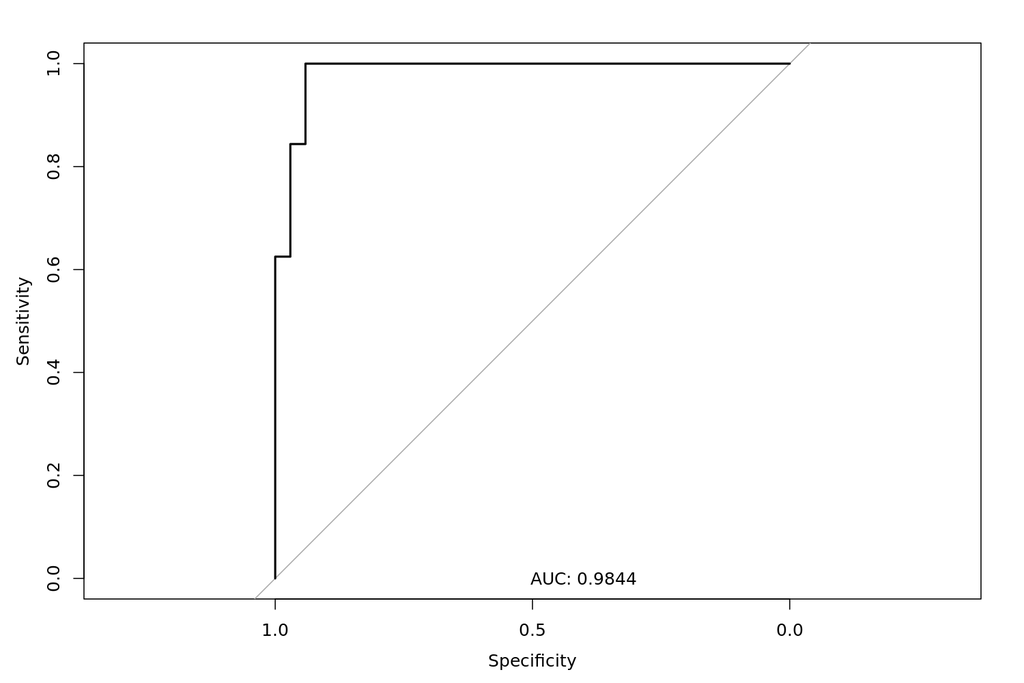

```r
knitr::include_graphics(filename)
```

#### SVM

```r
validation_results[["GSE102287"]]$svm$confmat
```

```
#> Confusion Matrix and Statistics
#>
#>           Reference
#> Prediction  0  1
#>          0 31  3
#>          1  3 29
#>
#>                Accuracy : 0.9091
#>                  95% CI : (0.8126, 0.9659)
#>     No Information Rate : 0.5152
#>     P-Value [Acc > NIR] : 6.84e-12
#>
#>                   Kappa : 0.818
#>
#>  Mcnemar's Test P-Value : 1
#>
#>             Sensitivity : 0.9062
#>             Specificity : 0.9118
#>          Pos Pred Value : 0.9062
#>          Neg Pred Value : 0.9118
#>              Prevalence : 0.4848
#>          Detection Rate : 0.4394
#>    Detection Prevalence : 0.4848
#>       Balanced Accuracy : 0.9090
#>
#>        'Positive' Class : 1
#>
```

```r
# create roc plot
filename <- paste0(plotdir, "ROC_validation_GSE102287_svm.png")
sigident::plot_rocplot(roc = validation_results[["GSE102287"]]$svm$roc,
                       filename = filename)
```

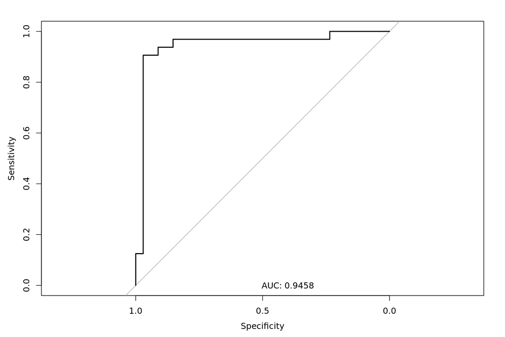

```r
knitr::include_graphics(filename)
```

#### RF

```r
validation_results[["GSE102287"]]$rf$confmat
```

```
#> Confusion Matrix and Statistics
#>
#>           Reference
#> Prediction  0  1
#>          0 20  1
#>          1 14 31
#>
#>                Accuracy : 0.7727
#>                  95% CI : (0.653, 0.8669)
#>     No Information Rate : 0.5152
#>     P-Value [Acc > NIR] : 1.493e-05
#>
#>                   Kappa : 0.5504
#>
#>  Mcnemar's Test P-Value : 0.001946
#>
#>             Sensitivity : 0.9688
#>             Specificity : 0.5882
#>          Pos Pred Value : 0.6889
#>          Neg Pred Value : 0.9524
#>              Prevalence : 0.4848
#>          Detection Rate : 0.4697
#>    Detection Prevalence : 0.6818
#>       Balanced Accuracy : 0.7785
#>
#>        'Positive' Class : 1
#>
```

```r
# create roc plot
filename <- paste0(plotdir, "ROC_validation_GSE102287_rf.png")
sigident::plot_rocplot(roc = validation_results[["GSE102287"]]$rf$roc,
                       filename = filename)
```

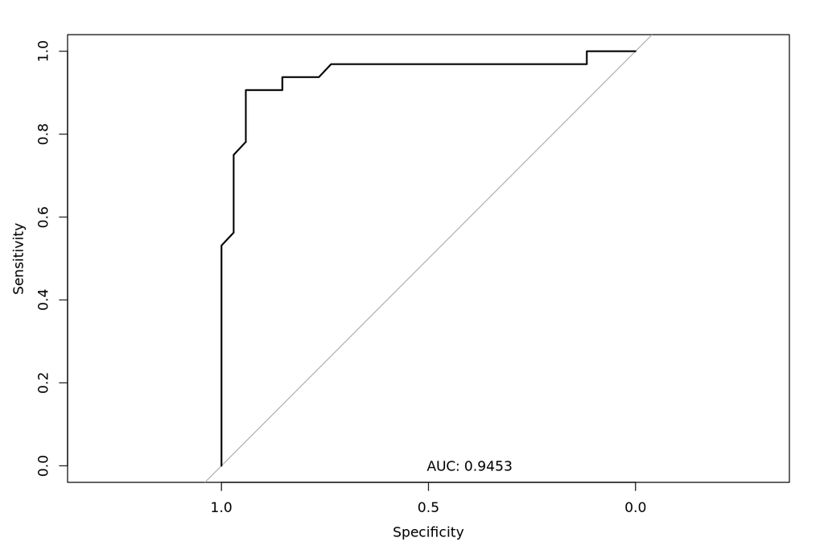

```r
knitr::include_graphics(filename)
```

#### KNN

```r
validation_results[["GSE102287"]]$knn$confmat
```

```
#> Confusion Matrix and Statistics
#>
#>           Reference
#> Prediction  0  1
#>          0 34 30
#>          1  0  2
#>
#>                Accuracy : 0.5455
#>                  95% CI : (0.4181, 0.6686)
#>     No Information Rate : 0.5152
#>     P-Value [Acc > NIR] : 0.3565
#>
#>                   Kappa : 0.0643
#>
#>  Mcnemar's Test P-Value : 1.192e-07
#>
#>             Sensitivity : 0.0625
#>             Specificity : 1.0000
#>          Pos Pred Value : 1.0000
#>          Neg Pred Value : 0.5312
#>              Prevalence : 0.4848
#>          Detection Rate : 0.0303
#>    Detection Prevalence : 0.0303
#>       Balanced Accuracy : 0.5312
#>
#>        'Positive' Class : 1
#>
```

```r
# create roc plot
filename <- paste0(plotdir, "ROC_validation_GSE102287_knn.png")
sigident::plot_rocplot(roc = validation_results[["GSE102287"]]$knn$roc,
                       filename = filename)
```

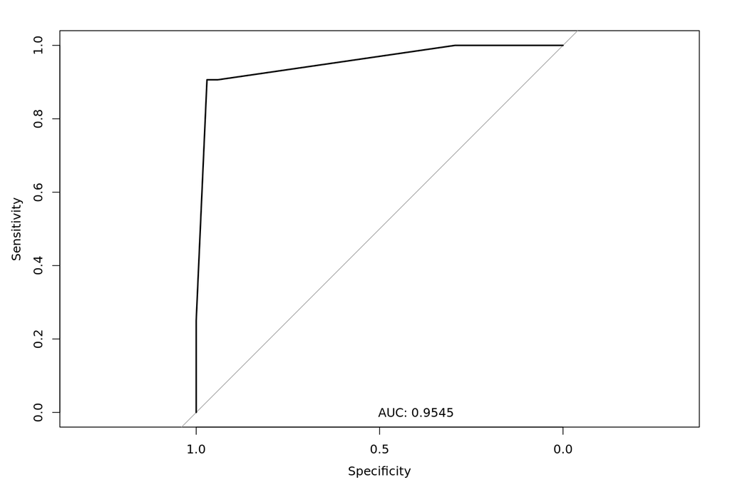

```r
knitr::include_graphics(filename)
```

```r
validation_results[["GSE102287"]] <- NULL
rm(validationstudylist, diagnostic_models, GSE102287, GSE33356)
gc()
```

# Identification of prognostic signatures

## Create a list that contains specifications of the study/studies that contain(s) survival time information

For the calculation of a prognostic signature it is first required to transform the phenoData containing the relevant survival data. In our example, only the study GSE19188 contains information on a subjects survival.  
In order to make the subsequent analyses possible, the list `discoverystudies_w_timedata`, containing metainformation about the validation study needs to be created. This nested list needs to contain the following elements:  
* the studyname, which is the key for a list containing  
+ `setid`: the index of the provided GEO set to be used  
+ `timecol`: the phenoData columm name of the survival time  
+ `status`: a list, containing the elements `statuscol` (name of phenoData column containing the survival status), `levels` (a list containing the originally used level-names of `statuscol`, namely `alive`, `deceased`, `na`)  
+ `targetcolname`: the name of the phenoData column containing the target-variable  
+ `controllevelname`: the level name of the controls of the column, specified in `targetcolname`  
+ `targetlevelname`: the level name of the subjects of interest in `targetcolname`  
+ `use_rawdata`: a logical value (TRUE or FALSE) that indicates, if the study is imported from the raw data

Since we already used the raw data above to load the study ‘GSE19188’ for the analyses of the DEGs, the enrichment analysis and the computation of the diagnostic signature, we here again import the study from the raw CEL files.

```r
discoverystudies_w_timedata <- list(
  "GSE19188" = list(
    setid = 1,
    timecol = "characteristics_ch1.2",
    status = list(
      statuscol = "characteristics_ch1.3",
      levels = list(alive = "status: alive",
                    deceased = "status: deceased",
                    na = "status: Not available")),
    targetcolname = "characteristics_ch1",
    controllevelname = "tissue type: healthy",
    targetlevelname = "tissue type: tumor",
    use_rawdata = TRUE)
)
```

## Identification of survival correlated genes

### Extract survival data

Next, the survival data needs to be extracted. `get_survival_time` results in a table named `survival_data`, containing samples (in our example of the class tumor) as rows, survival time and if an event (death) happened as columns. Additionally, the expression values of the selected DEGs (provided as parameter ‘genes’) are added as columns to the table.

```r
### Identification of survival correlated genes
survival_data <- sigident::get_survival_time(
  sample_metadata = sample_metadata,
  genes = genes,
  idtype = idtype,
  discoverystudies_w_timedata = discoverystudies_w_timedata,
  datadir = datadir
)
survival_table <- survival_data[["GSE19188"]]
```

```r
dim(survival_table)
```

```
#> [1]  91 701
```

```r
head(survival_table[,1:4])
```

```
#>           time status 217046_s_at 210081_at
#> GSM475656 12.5      2    3.346914  3.799257
#> GSM475661   NA     NA    2.623701  3.281502
#> GSM475662   NA     NA    3.619692  3.489756
#> GSM475664   NA     NA    5.045024  6.039511
#> GSM475668   NA     NA    2.806310  3.556768
#> GSM475670   NA     NA    2.563139  3.281502
```

### Compute univariate cox regression

Subsequently, an univariate Cox regression is conducted to identify survival correlated genes. The results containing the hazard rate within a 95% CI and corresponding p-values are exported as csv-file.

```r
surv_correlated <- sigident::univ_cox(survtable = survival_table,
                                      genes = genes)
# export table with survival correlated genes
data.table::fwrite(surv_correlated,
                   paste0(csvdir, "survival_correlated_genes.csv"))
```

```r
dim(surv_correlated)
```

```
#> [1] 22  5
```

```r
head(surv_correlated)
```

```
#>                      id  beta HR (95% CI for HR) wald_test p_value
#> 224822_at     224822_at -0.28   0.76 (0.62-0.92)       7.5   0.006
#> 210762_s_at 210762_s_at -0.26   0.77 (0.63-0.95)         6   0.015
#> 229367_s_at 229367_s_at -0.22    0.8 (0.66-0.98)       4.7   0.030
#> 205357_s_at 205357_s_at  -0.2      0.82 (0.68-1)         4   0.044
#> 222646_s_at 222646_s_at  0.23        1.3 (1-1.6)         4   0.045
#> 211696_x_at 211696_x_at -0.14      0.87 (0.75-1)         4   0.047
```

## Prognostic classifier and Kaplan-Meier estimator

In order to build an unbiased classifier that speparates subjects into high risk and low risk groups, expression data from the remaining discovery studies are required.

### Evaluate expression pattern (over-/underrepresentation)

The classifier takes the expression profiles of the identified survival correlated genes between tumor and non-tumor samples into account.

```r
classifier_studies <- c("GSE18842", "GSE19804")
expr_pattern <- sigident::generate_expression_pattern(
  classifier_studies = classifier_studies,
  sig_cov = surv_correlated,
  mergeset = mergeset,
  sample_metadata = sample_metadata
)
```

```r
dim(expr_pattern)
```

```
#> [1] 22  2
```

```r
head(expr_pattern)
```

```
#>          Gene Over/Under
#> 1   224822_at      Under
#> 2 210762_s_at      Under
#> 3 229367_s_at      Under
#> 4 205357_s_at      Under
#> 5 222646_s_at       Over
#> 6 211696_x_at      Under
```

### Apply the prognostic classifier on validation dataset

In order to apply the prognostic classifier on validation datasets, another list containing metainformation about these validation studies is required. This list (`validationstudiesinfo`) has the same structure as the above described list `discoverystudies_w_timedata`.  
However, the element `use_rawdata` is not allowed here. Furthermore, is allowed to to set `targetlevelname` to ‘NULL’, which indicates, that all included samples are of the class of interest and are taken into account to perform the analyses.

#### Create a list that contains specifications of the study that contains the validation information

```r
validationstudiesinfo <- list(
  "GSE30219" = list(
    setid = 1,
    timecol = "characteristics_ch1.9",
    status = list(
      statuscol = "characteristics_ch1.8",
      levels = list(alive = "status: ALIVE",
                    deceased = "status: DEAD",
                    na = "status: NTL")
    ),
    targetcolname = "source_name_ch1",
    controllevelname = "Non Tumoral Lung",
    targetlevelname = "Lung Tumour"),

  "GSE50081" = list(
    setid = 1,
    timecol = "characteristics_ch1.8",
    status = list(
      statuscol = "characteristics_ch1.9",
      levels = list(
        alive = "status: alive",
        deceased = "status: dead",
        na = NA)
    ),
    targetcolname = "characteristics_ch1.1",
    targetlevelname = paste(
      "histology: adenocarcinoma",
      "histology: adenosquamous carcinoma",
      "histology: large cell carcinoma",
      "histology: NSClarge cell carcinoma-mixed",
      "histology: NSCLC-favor adenocarcinoma",
      "histology: squamous cell carcinoma",
      "histology: squamous cell carcinoma X2",
      sep = "|||"
    ),
    controllevelname = NULL)
)
# if targetlevelname == NULL, the expression set will not be filtered further
# but instead, all samples will be used for calculations
```

```r
p_c <- sigident::prognostic_classifier(
  pattern_com = expr_pattern,
  validationstudiesinfo = validationstudiesinfo,
  datadir = datadir,
  idtype = idtype
)
```

### Validation study: GSE30219

Here we extract information on the study GSE30219.

```r
fit <- p_c[["GSE30219"]]$kaplan_estimator$fit
risktable <- p_c[["GSE30219"]]$risktable
```

```r
dim(risktable)
```

```
#> [1] 293   3
```

```r
head(risktable)
```

```
#>           time status groups
#> GSM748053  121      1      0
#> GSM748054   21      2      0
#> GSM748055   86      2      0
#> GSM748056   10      2      0
#> GSM748057   81      2      0
#> GSM748058   68      1      0
```

#### View proportional hazards regression models

```r
p_c[["GSE30219"]]$kaplan_estimator$res_cox
```

```
#> Call:
#> survival::coxph(formula = survival::Surv(time, status) ~ groups,
#>     data = risktable)
#>
#>          coef exp(coef) se(coef)     z        p
#> groups 0.5491    1.7317   0.1507 3.643 0.000269
#>
#> Likelihood ratio test=13.68  on 1 df, p=0.0002166
#> n= 278, number of events= 188
#>    (15 observations deleted due to missingness)
```

```r
fit
```

```
#> Call: survfit(formula = survival::coxph(survival::Surv(time, status) ~
#>     groups, data = risktable), newdata = new_df)
#>
#>     n events median 0.95LCL 0.95UCL
#> 1 278    188     88      57     134
#> 2 278    188     28      17      50
```

#### Plot prognostic Kaplan-Meier plot

```r
# create roc plot
filename <- paste0(plotdir, "GSE30219_Prognostic_Kaplan-Meier_Plot.png")
sigident::plot_survplot(
  fit = fit,
  risktable = risktable,
  filename = filename
)
```

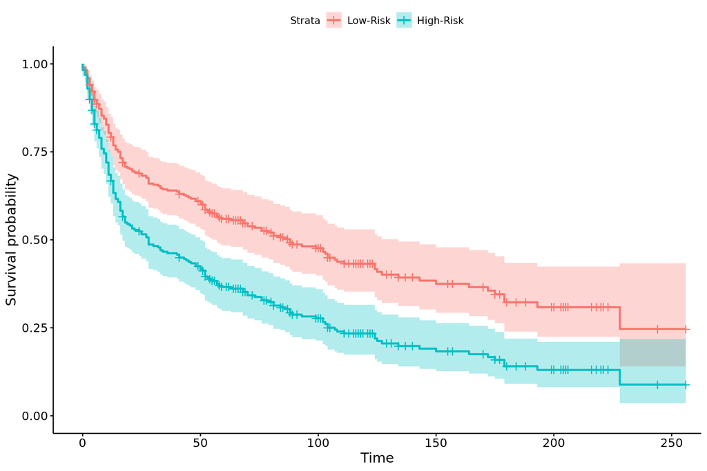

```r
knitr::include_graphics(filename)
```

### Validation study: GSE50081

```r
fit <- p_c[["GSE50081"]]$kaplan_estimator$fit
risktable <- p_c[["GSE50081"]]$risktable
```

```r
dim(risktable)
```

```
#> [1] 181   3
```

```r
head(risktable)
```

```
#>            time status groups
#> GSM1213669 4.11      2      1
#> GSM1213670 7.52      1      0
#> GSM1213671 7.32      1      0
#> GSM1213672 6.84      1      0
#> GSM1213673 1.91      2      1
#> GSM1213674 7.03      1      1
```

#### View proportional hazards regression models

```r
p_c[["GSE50081"]]$kaplan_estimator$res_cox
```

```
#> Call:
#> survival::coxph(formula = survival::Surv(time, status) ~ groups,
#>     data = risktable)
#>
#>          coef exp(coef) se(coef)     z      p
#> groups 0.5089    1.6635   0.2361 2.156 0.0311
#>
#> Likelihood ratio test=4.76  on 1 df, p=0.02919
#> n= 181, number of events= 75
```

```r
fit
```

```
#> Call: survfit(formula = survival::coxph(survival::Surv(time, status) ~
#>     groups, data = risktable), newdata = new_df)
#>
#>     n events median 0.95LCL 0.95UCL
#> 1 181     75   7.74    6.47      NA
#> 2 181     75   5.63    4.11      NA
```

#### Plot prognostic Kaplan-Meier plot

```r
# create roc plot
filename <- paste0(plotdir, "GSE50081_Prognostic_Kaplan-Meier_Plot.png")
sigident::plot_survplot(
  fit = fit,
  risktable = risktable,
  filename = filename
)
```

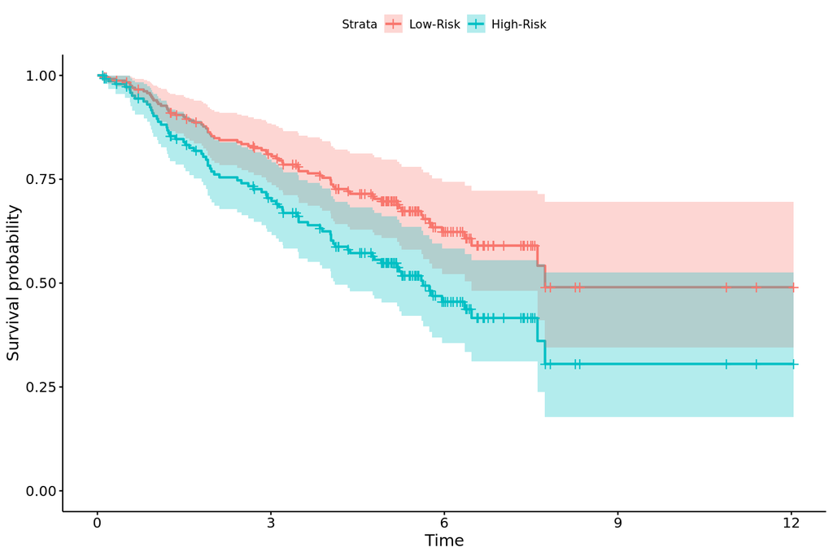

```r
knitr::include_graphics(filename)
```